# TCGA APA manuscript panels

Figure panels A and B and the all-cancer supplementary panel

07 August 2026

## Analysis overview

This notebook produces three standalone manuscript panels:

1. the distribution of significant cancer-versus-normal proximal poly(A)-site usage changes for DMAi and non-DMAi sites (Figure panel A);
2. the cancer-specific APA and PRMT1/PRMT5 expression panel restricted to the 21 cancers containing at least one significantly changed DMAi site (Figure panel B); and
3. the corresponding supplementary panel retaining all 26 cancers, including cancers without a significantly changed DMAi site.

## Methods

For each proximal poly(A) site and cancer type, usage change was defined as mean tumour usage minus mean normal-tissue usage. Panel A displays density estimates for sites passing the cancer-specific Benjamini–Hochberg-adjusted threshold of P < 0.05. Panel B displays all measured DMAi and non-DMAi sites, but its primary version is restricted to cancer types containing at least one significantly changed DMAi site. Cancers are ordered by their median usage change across all DMAi sites. The adjacent bars show the fraction of the 203 DMAi or 284 non-DMAi sites significant in each cancer.

The expression heatmap shows unscaled median cancer TPM for PRMT1 and PRMT5. Spearman correlations relate median cancer TPM to the median all-site DMAi usage change across the displayed cancer set. Two-sided asymptotic P values were calculated using `cor.test(..., exact = FALSE)` and adjusted by the Benjamini–Hochberg method across the ten prespecified candidate genes. The all-cancer supplementary version repeats the complete analysis across all 26 cancer types and therefore does not condition cancer inclusion on significant DMAi-site changes.

## Setup

```r
knitr::opts_chunk$set(
  echo = TRUE,
  warning = FALSE,
  message = FALSE,
  fig.align = "center",
  dpi = 160
)

required_packages <- c(
  "data.table", "ggplot2", "patchwork", "knitr", "scales"
)
missing_packages <- required_packages[
  !vapply(required_packages, requireNamespace, logical(1), quietly = TRUE)
]
if (length(missing_packages)) {
  stop(
    "Install the missing packages before running this notebook: ",
    paste(missing_packages, collapse = ", ")
  )
}

library(data.table)
library(ggplot2)
library(patchwork)
library(knitr)
library(scales)

find_repository_root <- function(start = getwd()) {
  candidate <- normalizePath(start, mustWork = TRUE)
  repeat {
    has_git_directory <- dir.exists(file.path(candidate, ".git"))
    has_repository_directories <-
      dir.exists(file.path(candidate, "Scripts")) &&
      (
        dir.exists(file.path(candidate, "Data")) ||
          dir.exists(file.path(candidate, "data"))
      )
    if (has_git_directory || has_repository_directories) {
      return(candidate)
    }
    parent <- dirname(candidate)
    if (identical(parent, candidate)) {
      stop("Could not locate the PRMT-APA repository root.")
    }
    candidate <- parent
  }
}

resolve_repository_path <- function(path, must_work = FALSE) {
  expanded_path <- path.expand(path)
  is_absolute <- grepl("^(/|[A-Za-z]:[/\\\\])", expanded_path)
  resolved_path <- if (is_absolute) {
    expanded_path
  } else {
    file.path(repository_root, expanded_path)
  }
  normalizePath(resolved_path, mustWork = must_work)
}

repository_root <- find_repository_root()
site_results_file <- resolve_repository_path(
  params$site_results_file,
  must_work = TRUE
)
expression_file <- resolve_repository_path(
  params$expression_file,
  must_work = TRUE
)
figure_output_dir <- resolve_repository_path(params$figure_output_dir)
results_output_dir <- resolve_repository_path(params$results_output_dir)
dir.create(figure_output_dir, recursive = TRUE, showWarnings = FALSE)
dir.create(results_output_dir, recursive = TRUE, showWarnings = FALSE)
figure_output_dir <- normalizePath(figure_output_dir, mustWork = TRUE)
results_output_dir <- normalizePath(results_output_dir, mustWork = TRUE)

apa_colours <- c(
  "DMAi" = "#FF594E",
  "non_DMAi" = "#1A85FF"
)
candidate_genes <- c(
  "PRMT1", "PRMT2", "PRMT3", "CARM1", "PRMT6",
  "PRMT5", "PRMT9", "MTAP", "PCF11", "CSTF2"
)
displayed_genes <- c("PRMT1", "PRMT5")

theme_panel <- theme_bw(base_size = 14) +
  theme(
    panel.grid.minor = element_blank(),
    panel.grid.major = element_line(colour = "#E8E8E8", linewidth = 0.35),
    axis.text = element_text(colour = "#222222"),
    legend.position = "top"
  )

format_probability <- function(x) {
  ifelse(x < 0.001, format.pval(x, digits = 2), sprintf("%.3f", x))
}
```

## Read and validate the source data

```r
site_results <- fread(site_results_file)
expression <- fread(expression_file)

required_site_columns <- c(
  "tissue", "disease_type", "Identifier", "FileName",
  "mean_healthy", "mean_disease", "p_adjusted", "significant"
)
required_expression_columns <- c(
  "tissue", "disease_type", "project_id", "gene_name",
  "median_cancer_tpm"
)
missing_site_columns <- setdiff(required_site_columns, names(site_results))
missing_expression_columns <- setdiff(
  required_expression_columns,
  names(expression)
)
if (length(missing_site_columns)) {
  stop(
    "The site-results file lacks required columns: ",
    paste(missing_site_columns, collapse = ", ")
  )
}
if (length(missing_expression_columns)) {
  stop(
    "The expression file lacks required columns: ",
    paste(missing_expression_columns, collapse = ", ")
  )
}

cancer_key <- unique(
  expression[, .(tissue, disease_type, project_id)]
)
ambiguous_cancer_labels <- cancer_key[
  , .N,
  by = .(tissue, disease_type)
][N != 1L]
if (nrow(ambiguous_cancer_labels)) {
  stop("Tissue/disease labels do not map uniquely to TCGA projects.")
}

site_results <- merge(
  site_results,
  cancer_key,
  by = c("tissue", "disease_type"),
  all.x = TRUE
)
if (anyNA(site_results$project_id)) {
  stop("At least one APA row could not be mapped to a TCGA project.")
}
site_results[, delta_usage := mean_disease - mean_healthy]
site_results[, project_short := sub("^TCGA-", "", project_id)]
site_results[, FileName := factor(
  FileName,
  levels = c("DMAi", "non_DMAi")
)]

candidate_expression <- expression[
  gene_name %chin% candidate_genes &
    project_id %chin% unique(site_results$project_id),
  .(project_id, gene_name, median_cancer_tpm)
]
candidate_expression[, project_short := sub("^TCGA-", "", project_id)]

stopifnot(
  uniqueN(site_results$project_id) == 26L,
  uniqueN(site_results[FileName == "DMAi", Identifier]) == 203L,
  uniqueN(site_results[FileName == "non_DMAi", Identifier]) == 284L,
  nrow(candidate_expression) == 26L * length(candidate_genes),
  all(is.finite(candidate_expression$median_cancer_tpm))
)

input_inventory <- data.table(
  input = c("APA site/cancer results", "Candidate-gene expression"),
  rows = c(nrow(site_results), nrow(candidate_expression)),
  cancer_projects = c(
    uniqueN(site_results$project_id),
    uniqueN(candidate_expression$project_id)
  )
)
kable(input_inventory, caption = "Panel input data")
```

Panel input data

| input | rows | cancer_projects |
| --- | --- | --- |
| APA site/cancer results | 12642 | 26 |
| Candidate-gene expression | 260 | 26 |

## Cancer-level summaries

```r
total_sites <- unique(
  site_results[, .(FileName, Identifier)]
)[, .(n_total_sites = .N), by = FileName]

cancer_scores <- site_results[, .(
  all_median_delta_usage_DMAi = median(
    delta_usage[FileName == "DMAi"],
    na.rm = TRUE
  ),
  has_significant_DMAi_site = any(
    FileName == "DMAi" & significant,
    na.rm = TRUE
  )
), by = .(project_id, project_short)]

significant_counts <- site_results[
  significant == TRUE,
  .(n_significant = .N),
  by = .(project_id, project_short, FileName)
]
proportion_data <- merge(
  CJ(
    project_id = unique(site_results$project_id),
    FileName = factor(
      c("DMAi", "non_DMAi"),
      levels = levels(site_results$FileName)
    ),
    unique = TRUE
  ),
  unique(site_results[, .(project_id, project_short)]),
  by = "project_id"
)
proportion_data <- merge(
  proportion_data,
  significant_counts,
  by = c("project_id", "project_short", "FileName"),
  all.x = TRUE
)
proportion_data[is.na(n_significant), n_significant := 0L]
proportion_data <- merge(
  proportion_data,
  total_sites,
  by = "FileName",
  all.x = TRUE
)
proportion_data[, proportion_significant := n_significant / n_total_sites]

significant_dmai_projects <- cancer_scores[
  has_significant_DMAi_site == TRUE,
  project_id
]
stopifnot(
  nrow(cancer_scores) == 26L,
  length(significant_dmai_projects) == 21L
)

kable(
  cancer_scores[order(-all_median_delta_usage_DMAi)],
  digits = 4,
  caption = "Cancer inclusion and all-site DMAi usage score"
)
```

Cancer inclusion and all-site DMAi usage score

| project_id | project_short | all_median_delta_usage_DMAi | has_significant_DMAi_site |
| --- | --- | --- | --- |
| TCGA-CESC | CESC | 0.0834 | TRUE |
| TCGA-SARC | SARC | 0.0786 | FALSE |
| TCGA-LUSC | LUSC | 0.0667 | TRUE |
| TCGA-UCEC | UCEC | 0.0636 | TRUE |
| TCGA-UCS | UCS | 0.0448 | TRUE |
| TCGA-LUAD | LUAD | 0.0378 | TRUE |
| TCGA-COAD | COAD | 0.0298 | TRUE |
| TCGA-GBM | GBM | 0.0254 | TRUE |
| TCGA-READ | READ | 0.0254 | TRUE |
| TCGA-BLCA | BLCA | 0.0244 | TRUE |
| TCGA-BRCA | BRCA | 0.0235 | TRUE |
| TCGA-ESCA | ESCA | 0.0201 | TRUE |
| TCGA-KIRC | KIRC | 0.0128 | TRUE |
| TCGA-KICH | KICH | 0.0099 | TRUE |
| TCGA-HNSC | HNSC | 0.0088 | TRUE |
| TCGA-PRAD | PRAD | 0.0034 | TRUE |
| TCGA-PAAD | PAAD | 0.0027 | FALSE |
| TCGA-STAD | STAD | 0.0017 | TRUE |
| TCGA-LIHC | LIHC | -0.0001 | TRUE |
| TCGA-LGG | LGG | -0.0025 | TRUE |
| TCGA-ACC | ACC | -0.0040 | FALSE |
| TCGA-CHOL | CHOL | -0.0119 | TRUE |
| TCGA-THCA | THCA | -0.0158 | TRUE |
| TCGA-KIRP | KIRP | -0.0320 | TRUE |
| TCGA-PCPG | PCPG | -0.0416 | FALSE |
| TCGA-THYM | THYM | -0.0499 | FALSE |

## Panel A: significant-site usage distributions

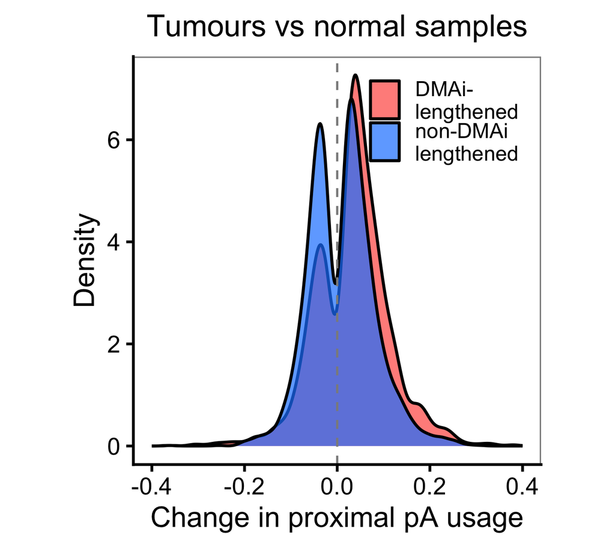

```r
panel_a_data <- site_results[
  significant == TRUE & is.finite(delta_usage)
]
panel_a_data[, display_category := factor(
  as.character(FileName),
  levels = c("DMAi", "non_DMAi"),
  labels = c("DMAi-\nlengthened", "non-DMAi\nlengthened")
)]

panel_a_plot <- ggplot(
  panel_a_data,
  aes(delta_usage, fill = display_category)
) +
  geom_density(alpha = 0.70, linewidth = 0.75, colour = "black") +
  geom_vline(
    xintercept = 0,
    linetype = "dashed",
    colour = "grey55",
    linewidth = 0.55
  ) +
  scale_fill_manual(
    values = c(
      "DMAi-\nlengthened" = apa_colours[["DMAi"]],
      "non-DMAi\nlengthened" = apa_colours[["non_DMAi"]]
    ),
    name = NULL
  ) +
  scale_x_continuous(
    limits = c(-0.4, 0.4),
    breaks = seq(-0.4, 0.4, by = 0.2)
  ) +
  labs(
    title = "Tumours vs normal samples",
    x = "Change in proximal pA usage",
    y = "Density"
  ) +
  theme_classic(base_size = 15) +
  theme(
    aspect.ratio = 1,
    panel.border = element_rect(fill = NA, colour = "grey55"),
    plot.title = element_text(hjust = 0.5, size = 16),
    axis.title = element_text(size = 15),
    axis.text = element_text(size = 12.5),
    legend.position = "inside",
    legend.position.inside = c(0.98, 0.98),
    legend.justification = c(1, 1),
    legend.text = element_text(size = 11),
    legend.key.height = grid::unit(0.55, "lines"),
    legend.background = element_blank()
  )

panel_a_plot
```

```r
panel_a_file <- file.path(
  figure_output_dir,
  "tcga_apa_panel_a_significant_site_density.pdf"
)
ggsave(
  panel_a_file,
  panel_a_plot,
  width = 4.5,
  height = 4,
  units = "in",
  device = grDevices::pdf,
  useDingbats = FALSE
)
```

## Panel B plotting function

```r
calculate_candidate_correlations <- function(project_ids, analysis_label) {
  correlation_data <- merge(
    candidate_expression[project_id %chin% project_ids],
    cancer_scores[, .(
      project_id,
      all_median_delta_usage_DMAi
    )],
    by = "project_id"
  )
  correlations <- correlation_data[, .(
    n_cancer_types = .N,
    spearman_rho = cor(
      median_cancer_tpm,
      all_median_delta_usage_DMAi,
      method = "spearman"
    ),
    p_value = suppressWarnings(cor.test(
      median_cancer_tpm,
      all_median_delta_usage_DMAi,
      method = "spearman",
      exact = FALSE
    )$p.value)
  ), by = gene_name]
  correlations[, p_adjusted := p.adjust(p_value, method = "BH")]
  correlations[, analysis := analysis_label]
  setcolorder(
    correlations,
    c(
      "analysis", "gene_name", "n_cancer_types", "spearman_rho",
      "p_value", "p_adjusted"
    )
  )
  correlations
}

make_panel_b <- function(project_ids, analysis_label) {
  cancer_order <- cancer_scores[
    project_id %chin% project_ids
  ][order(all_median_delta_usage_DMAi), project_short]

  plot_sites <- copy(site_results[project_id %chin% project_ids])
  plot_sites[, project_short := factor(
    project_short,
    levels = cancer_order
  )]
  plot_proportions <- copy(
    proportion_data[project_id %chin% project_ids]
  )
  plot_proportions[, project_short := factor(
    project_short,
    levels = cancer_order
  )]

  correlations <- calculate_candidate_correlations(
    project_ids,
    analysis_label
  )
  displayed_correlations <- correlations[
    gene_name %chin% displayed_genes
  ][match(displayed_genes, gene_name)]
  gene_labels <- setNames(
    sprintf(
      "%s\nrho=%.2f\nP=%s\nq=%s",
      displayed_correlations$gene_name,
      displayed_correlations$spearman_rho,
      format_probability(displayed_correlations$p_value),
      format_probability(displayed_correlations$p_adjusted)
    ),
    displayed_correlations$gene_name
  )

  expression_plot_data <- copy(candidate_expression[
    project_id %chin% project_ids & gene_name %chin% displayed_genes
  ])
  expression_plot_data[, project_short := factor(
    project_short,
    levels = cancer_order
  )]
  expression_plot_data[, gene_name := factor(
    gene_name,
    levels = displayed_genes
  )]

  boxplot <- ggplot(
    plot_sites,
    aes(delta_usage, project_short, fill = FileName)
  ) +
    geom_vline(
      xintercept = 0,
      linetype = "dotted",
      colour = "#555555"
    ) +
    geom_boxplot(
      position = position_dodge(width = 0.8),
      width = 0.68,
      outlier.size = 0.45,
      linewidth = 0.35
    ) +
    scale_fill_manual(
      values = apa_colours,
      labels = c(DMAi = "DMAi", non_DMAi = "non-DMAi"),
      name = "APA category"
    ) +
    scale_x_continuous(
      limits = c(-0.22, 0.24),
      breaks = c(-0.2, -0.1, 0, 0.1, 0.2)
    ) +
    labs(
      x = paste0(
        "Tumour – normal change in\n",
        "proximal poly(A) site usage"
      ),
      y = "TCGA project"
    ) +
    theme_panel +
    theme(
      text = element_text(size = 14),
      axis.text = element_text(size = 12.5),
      axis.title = element_text(size = 14.5),
      legend.title = element_text(size = 13.5),
      legend.text = element_text(size = 12.5),
      legend.position = "top"
    )

  proportion_plot <- ggplot(
    plot_proportions,
    aes(proportion_significant, project_short, fill = FileName)
  ) +
    geom_col(position = position_dodge(width = 0.8), width = 0.72) +
    scale_fill_manual(values = apa_colours, guide = "none") +
    scale_x_continuous(
      limits = c(0, 1),
      breaks = c(0, 0.25, 0.5, 0.75, 1),
      labels = label_number(accuracy = 0.01)
    ) +
    labs(
      x = paste0(
        "Fraction of sites with significant\n",
        "tumour-associated APA"
      ),
      y = NULL
    ) +
    theme_panel +
    theme(
      text = element_text(size = 14),
      axis.text.x = element_text(size = 12.5),
      axis.text.y = element_blank(),
      axis.title.x = element_text(size = 14.5),
      axis.ticks.y = element_blank(),
      legend.position = "none"
    )

  tpm_limits <- c(
    20,
    ceiling(
      max(
        candidate_expression[
          gene_name %chin% displayed_genes,
          median_cancer_tpm
        ]
      ) / 20
    ) * 20
  )
  expression_heatmap <- ggplot(
    expression_plot_data,
    aes(gene_name, project_short, fill = median_cancer_tpm)
  ) +
    geom_tile(colour = "white", linewidth = 0.28) +
    scale_x_discrete(labels = gene_labels) +
    scale_fill_gradient(
      low = "white",
      high = "black",
      limits = tpm_limits,
      breaks = seq(tpm_limits[1L], tpm_limits[2L], by = 20),
      oob = squish,
      labels = label_number(accuracy = 1),
      name = "Median\ncancer TPM"
    ) +
    labs(x = NULL, y = NULL) +
    theme_panel +
    theme(
      panel.grid = element_blank(),
      text = element_text(size = 14),
      axis.text.x = element_text(size = 12, lineheight = 0.94),
      axis.text.y = element_blank(),
      axis.ticks.y = element_blank(),
      legend.position = "right",
      legend.title = element_text(size = 13),
      legend.text = element_text(size = 12)
    )

  combined_plot <- (
    boxplot + proportion_plot + expression_heatmap
  ) +
    plot_layout(widths = c(3.2, 1.2, 1.55))

  list(
    plot = combined_plot,
    cancer_order = data.table(
      analysis = analysis_label,
      order = seq_along(cancer_order),
      project_short = cancer_order
    ),
    proportions = plot_proportions,
    correlations = correlations
  )
}
```

## Panel B: cancers with a significant DMAi site

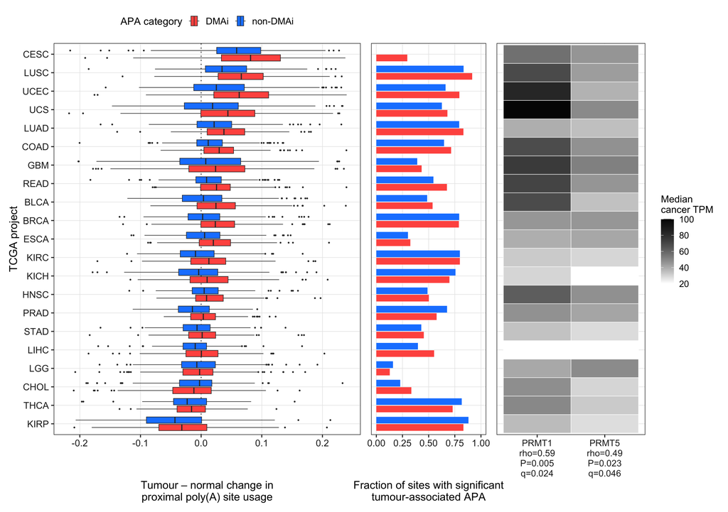

```r
panel_b_main <- make_panel_b(
  significant_dmai_projects,
  "Main panel: 21 cancers with a significant DMAi site"
)
panel_b_main$plot
```

```r
panel_b_main_file <- file.path(
  figure_output_dir,
  "tcga_apa_panel_b_significant_dmai_cancers.pdf"
)
ggsave(
  panel_b_main_file,
  panel_b_main$plot,
  width = 13.5,
  height = 9.5,
  units = "in",
  device = grDevices::pdf,
  useDingbats = FALSE
)
```

## Supplementary panel B: all cancers

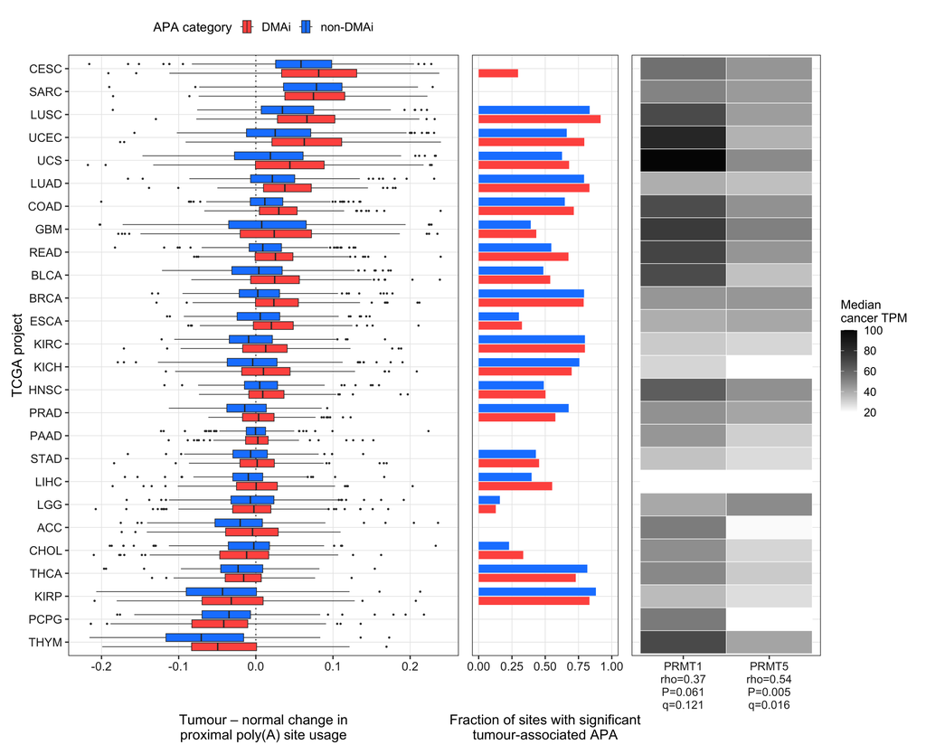

```r
panel_b_all_cancers <- make_panel_b(
  cancer_scores$project_id,
  "Supplementary panel: all 26 cancers"
)
panel_b_all_cancers$plot
```

```r
panel_b_all_cancers_file <- file.path(
  figure_output_dir,
  "tcga_apa_panel_b_all_cancers_supplement.pdf"
)
ggsave(
  panel_b_all_cancers_file,
  panel_b_all_cancers$plot,
  width = 13.5,
  height = 11,
  units = "in",
  device = grDevices::pdf,
  useDingbats = FALSE
)
```

## Correlation results

```r
panel_correlations <- rbindlist(list(
  panel_b_main$correlations,
  panel_b_all_cancers$correlations
))
kable(
  panel_correlations[gene_name %chin% displayed_genes][
    order(analysis, match(gene_name, displayed_genes))
  ],
  digits = 4,
  caption = paste(
    "PRMT1 and PRMT5 correlations displayed beneath the expression",
    "heatmaps; BH correction was across ten candidate genes"
  )
)
```

PRMT1 and PRMT5 correlations displayed beneath the expression heatmaps; BH correction was across ten candidate genes

| analysis | gene_name | n_cancer_types | spearman_rho | p_value | p_adjusted |
| --- | --- | --- | --- | --- | --- |
| Main panel: 21 cancers with a significant DMAi site | PRMT1 | 21 | 0.5909 | 0.0048 | 0.0240 |
| Main panel: 21 cancers with a significant DMAi site | PRMT5 | 21 | 0.4935 | 0.0230 | 0.0460 |
| Supplementary panel: all 26 cancers | PRMT1 | 26 | 0.3730 | 0.0606 | 0.1211 |
| Supplementary panel: all 26 cancers | PRMT5 | 26 | 0.5350 | 0.0049 | 0.0162 |

## Reproducibility outputs

```r
panel_cancer_orders <- rbindlist(list(
  panel_b_main$cancer_order,
  panel_b_all_cancers$cancer_order
))
panel_proportions <- rbindlist(list(
  copy(panel_b_main$proportions)[, analysis := panel_b_main$cancer_order$analysis[1L]],
  copy(panel_b_all_cancers$proportions)[
    , analysis := panel_b_all_cancers$cancer_order$analysis[1L]
  ]
), use.names = TRUE, fill = TRUE)

fwrite(
  panel_a_data,
  file.path(results_output_dir, "tcga_apa_panel_a_source_data.tsv"),
  sep = "\t"
)
fwrite(
  panel_cancer_orders,
  file.path(results_output_dir, "tcga_apa_panel_b_cancer_order.tsv"),
  sep = "\t"
)
fwrite(
  panel_proportions,
  file.path(results_output_dir, "tcga_apa_panel_b_site_proportions.tsv"),
  sep = "\t"
)
fwrite(
  panel_correlations,
  file.path(results_output_dir, "tcga_apa_panel_b_expression_correlations.tsv"),
  sep = "\t"
)

output_inventory <- data.table(
  panel = c(
    "Figure panel A",
    "Figure panel B",
    "Supplementary panel B"
  ),
  file = c(
    panel_a_file,
    panel_b_main_file,
    panel_b_all_cancers_file
  )
)
kable(output_inventory, caption = "Generated PDF panels")
```

Generated PDF panels

| panel | file |
| --- | --- |
| Figure panel A | /Users/capitac/repos/PRMT-APA/Scripts/Figure_5_6_S8_S9/output/pdf/tcga_apa_panel_a_significant_site_density.pdf |
| Figure panel B | /Users/capitac/repos/PRMT-APA/Scripts/Figure_5_6_S8_S9/output/pdf/tcga_apa_panel_b_significant_dmai_cancers.pdf |
| Supplementary panel B | /Users/capitac/repos/PRMT-APA/Scripts/Figure_5_6_S8_S9/output/pdf/tcga_apa_panel_b_all_cancers_supplement.pdf |